# Density Estimation

Ryan Miller

## Introduction

- In statistics, we often adopt the notion that data arises from some sort of underlying **distribution**
- A **density function** describes the relative frequencies of certain values of a variable
  - All density functions must integrate to 1, so the area under the density curve of $X$ between points $a$ and $a$ determines the probability that we see a data-point having an $X$ value between $a$ and $b$
  - The *normal curve*, defined mathetmatically by $f(x) = \frac{1}{\sqrt{2\pi\sigma^2}}e^{-\frac{(x - \mu)^2}{2\sigma^2}}$, is an example of a density function
  - The figure below illustrates a familiar feature of the *standard normal density*

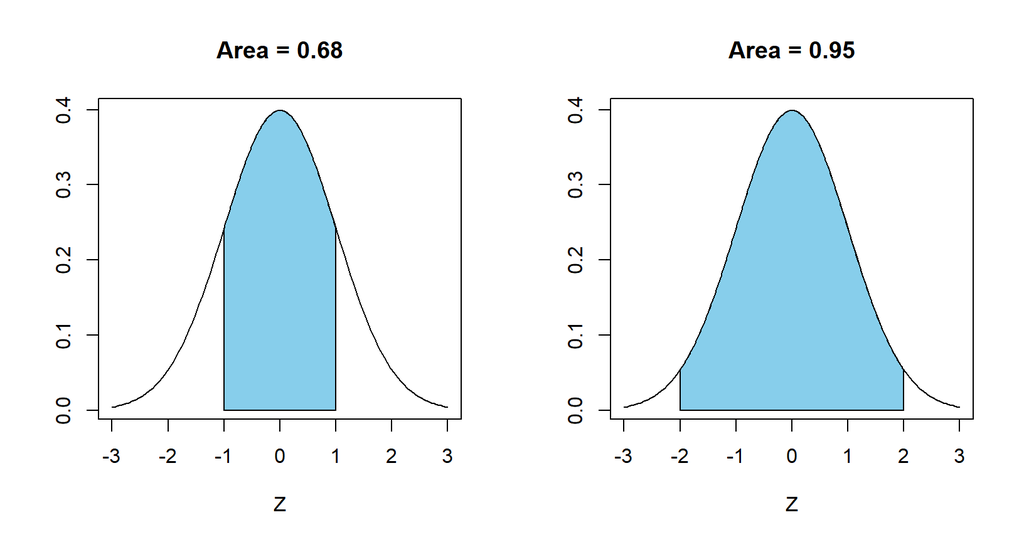

## Why Worry About Densities?

- Below is a rugplot of a variable $X$, which shows every individual data-point, and a histogram, which aggregates the data to display relative frequencies (ie: the histograms estimates the density function of $X$)
  - Which do you think is more useful in understanding $X$?

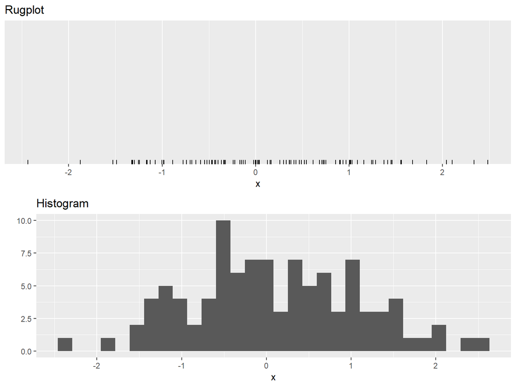

## Histograms and Density Estimation

- Whenever we are interested the relative frequencies of a variable, we should consider estimating its density function
- Histograms provide a coarse method of density estimation
  - In this example, $X$ consists of $n=100$ draws from the standard normal distribution
  - Notice the histogram of $X$ only vaguely resembles the underlying normal curve (shown in red)
- Can we do better?

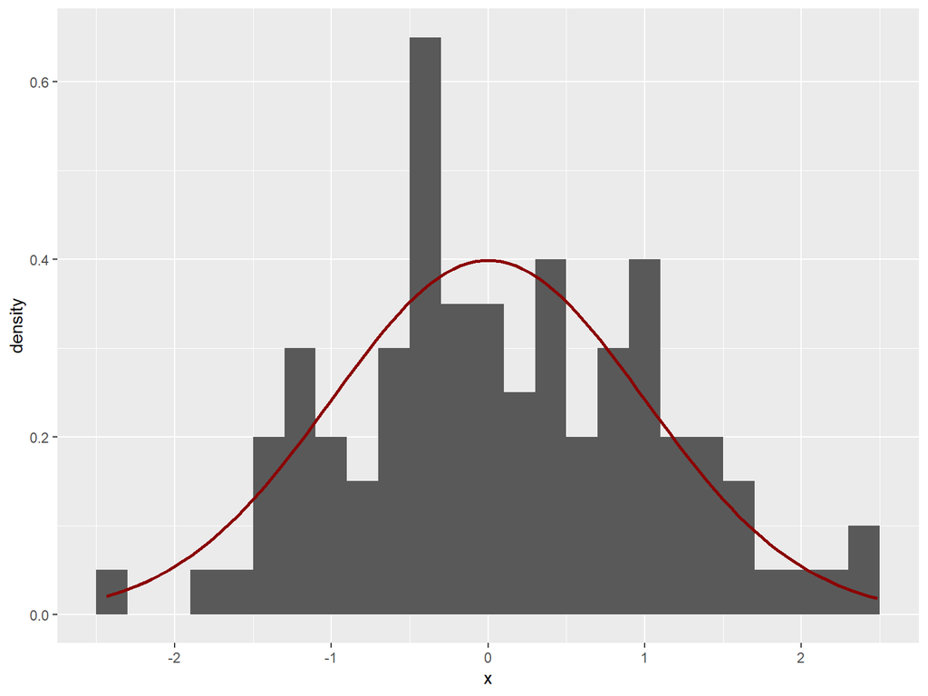

## Kernel Density Estimation

- Histograms divide the data into buckets, treating all data-points with a bucket as equal
  - This means data-points near the boundaries of a bucket contribute just as much as those near the midpoint
  - The result is a jagged density estimate that is highly sensitive to how the buckets are defined
- Alternatively, **Kernel density estimation** (KDE) takes a point-by-point approach to density estimation
  - Before explaining the method, let’s first see a density estimate that KDE produces (shown in blue)

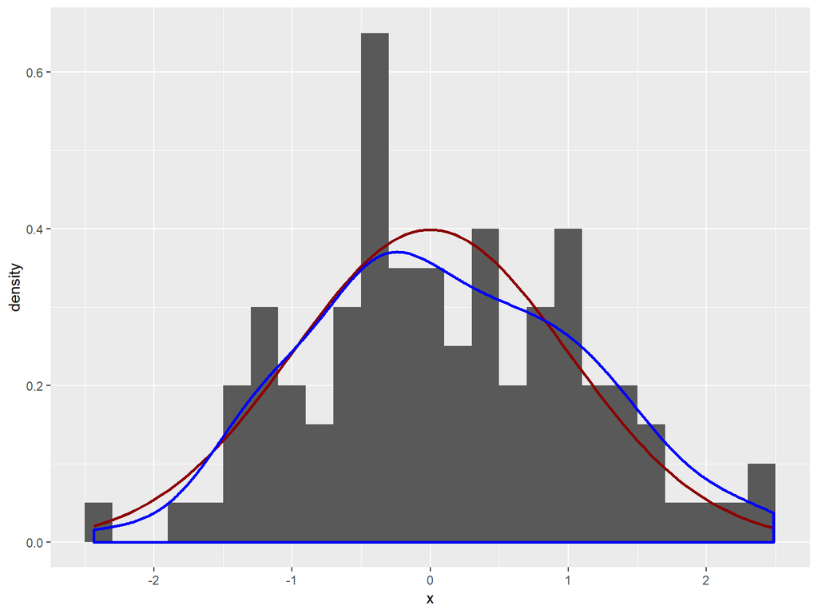

## Kernel Density Estimation

- In our example, the kernel density estimate is a much more accurate representation of the underlying density of $X$ than the histogram
- KDE works by giving each datapoint a kernel (most often a normal density), these kernels are then aggregated (weighting each by $1/n$ and then “stacking”) to produce an overall density estimate

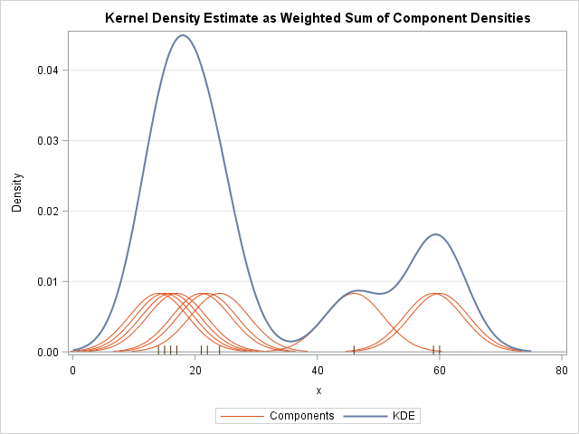

## Bandwidth

- It is natural for the mean (center) of each data-point’s kernel to be the value of the datapoint itself
- The standard deviation (spread) of the normal kernel is something the analyst must decide
  - This standard deviation is known as **bandwidth**
  - Bandwidth governs how smooth a kernel density estimate is, in `ggplot` it is controlled by the `bw` argument in `geom_density()`

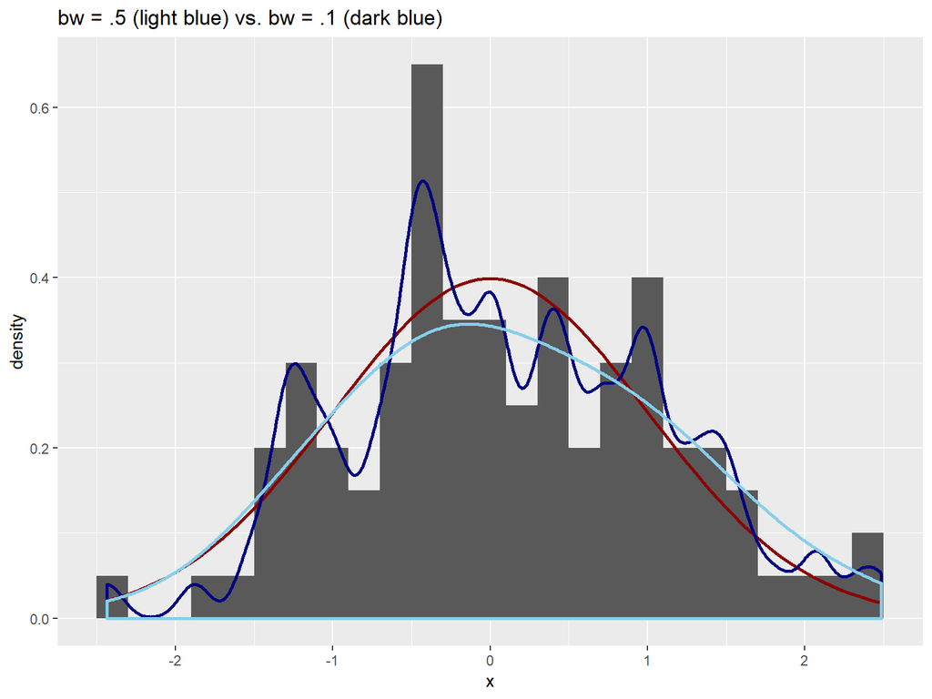

## Other Kernels

- Normal kernels are usually a reasonable choice, but there are other possibilities such as rectangles or triangles
  - The shape of these kernels is particularly noticeable in the low density region near -2
  - The type of kernel can be changed using the `kernel` argument in `geom_density()`, for example `kernel = "rectangular"`

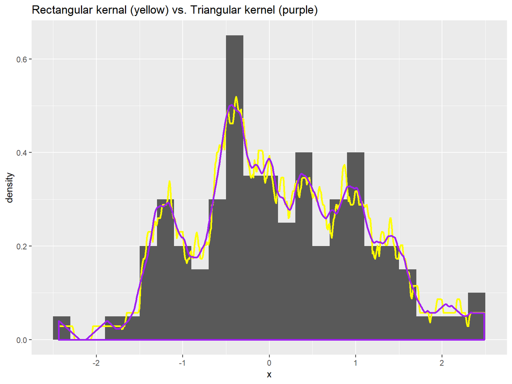

## KDE in Two-Dimensions

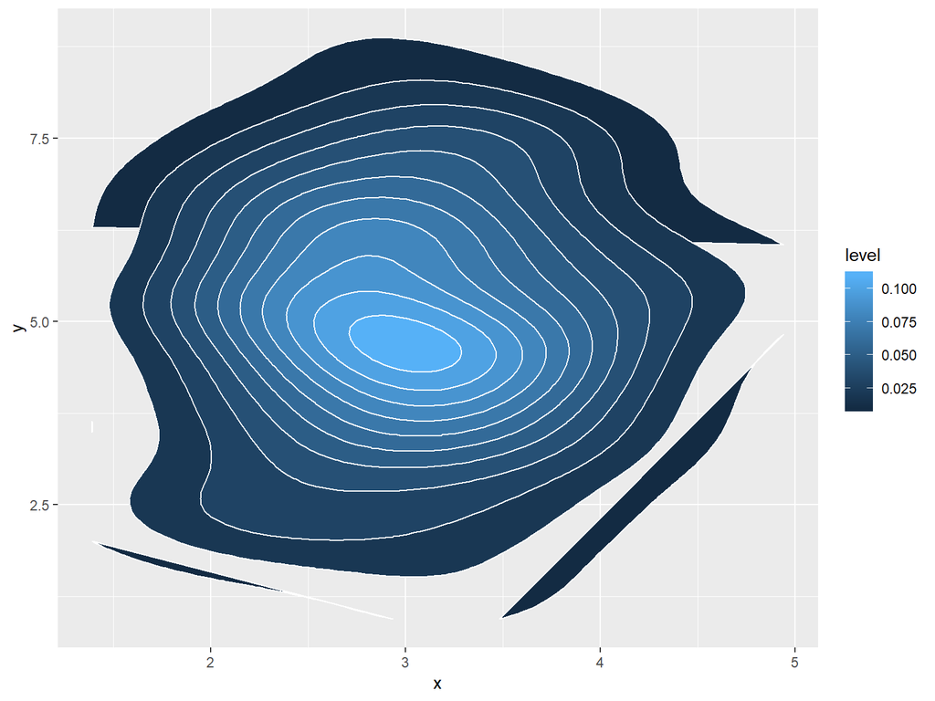

```r
set.seed(11)
xx <- rnorm(200, mean = 3, sd = .7)
yy <- rnorm(200, mean = 5, sd = 1.7)
df <- data.frame(x = xx, y = yy)

ggplot(df, aes(x = x, y = y)) + stat_density_2d(aes(fill = stat(level)), geom = "polygon", color = "white", h = c(2,2))
```

## Example - Diabetes Among Pima Indians

- The graphs below show the blood glucose measurements of 736 Pima Indians following a glucose tolerance test
- Based upon the histograms, it looks most diabetics had higher blood glucose measurements than non-diabetics
  - But these data are noisy, and the different numbers of diabetics/non-diabetics complicates the comparison
  - In contrast, KDE clearly clearly shows the relative likelihood of diabetes is much higher at high blood glucose levels

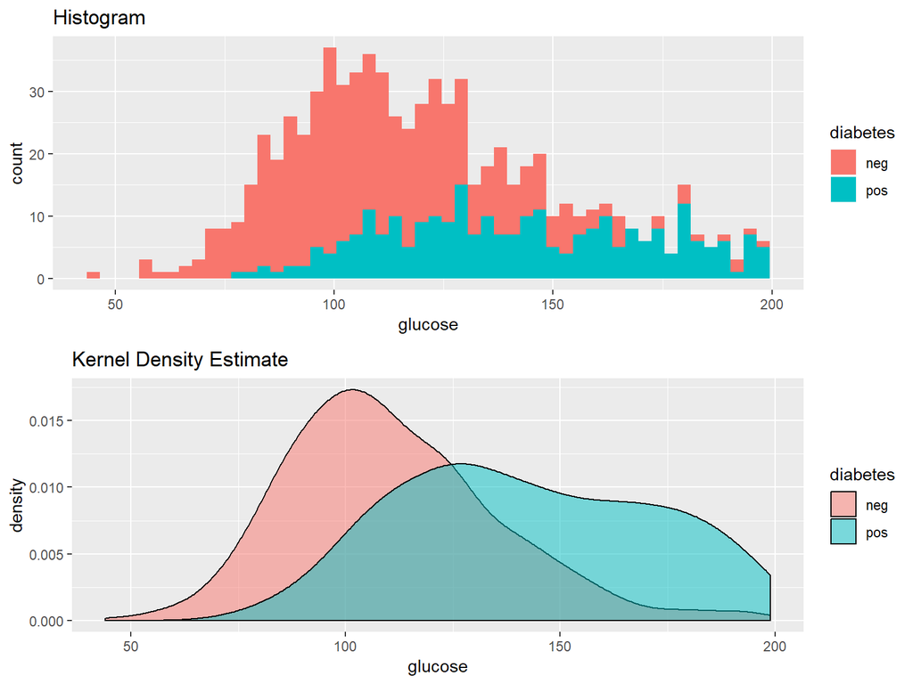

## Example - Diabetes Among Pima Indians

- We can also compare the relative frequencies of diabetics and non-diabetics in two-dimensions
  - Diabetics tend to have both higher mass and higher glucose

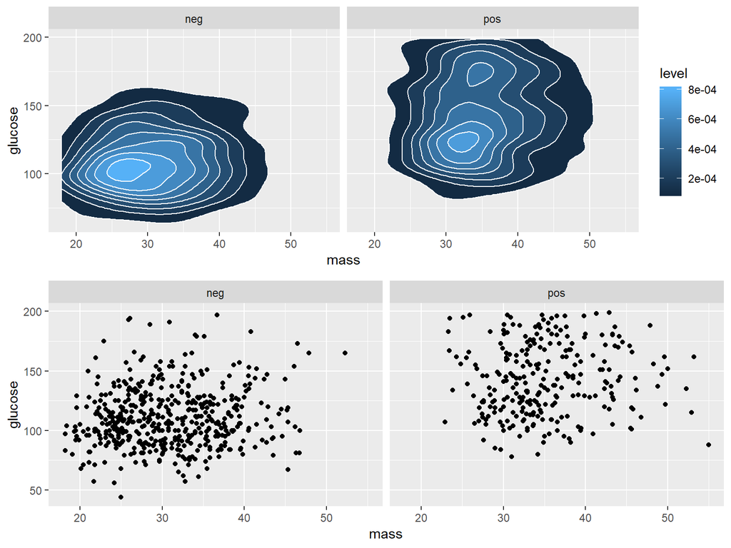

## Example - Diamond Prices

- Even with transparency of `alpha = .1`, it is hard to judge the relative concentrations of data-points in the scatterplot

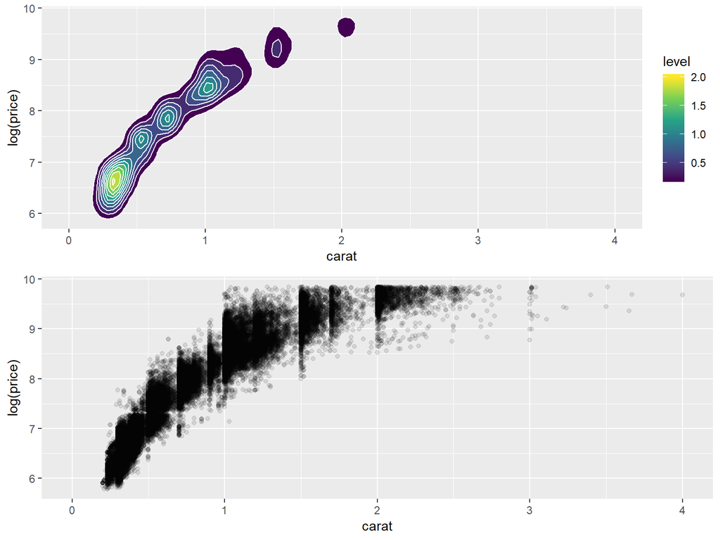

## Takeaways

- Kernel density estimation is a useful strategy for representing the distribution of numeric variables
- For large datasets, density estimates can be easier to interpret than scatterplots or rugplots